# Final Project

Juan Arredondo

## Objective

This project should allow you to apply the information you’ve learned in the course to a new dataset. The structure of the final project will be similar to a white paper. The goal of this project is for you to learn how to identify and address a problem with text data and communicate your findings in report that others can read. The dataset must be related to language or language processing in some way. You must use an analysis we learned in class.

## Instructions

The final document should be a knitted HTML/PDF/Word document from a Markdown file. You will turn in the knitted document. Be sure to spell and grammar check your work! The following sections should be included:

### Introduction

Introduce your research topic (the problem) and briefly review related work. Be sure to answer these two questions: (1) Why does this topic matter and (2) What is the background knowledge that someone would need to understand the field or area that you have decided to investigate? In this section, you should include sources that help explain the background area and cite them in APA style. 5-10 articles across the paper would be appropriate - be sure to include these! They are part of the grade! This section should be 3-5 paragraphs.

### Research Question

Given a dataset of Game of Thrones reviews from users and critics, this study aims to answer the following research questions:

- How do viewers/critics’ emotional tone change across each episode review?
- How do the viewers’ emotional responses to the episodes based on the language and sentiment in their discussion comments compare to episode ratings by critics?
- What are the most common themes and topics in TV show discussion threads, and how do they vary across different critics and viewers’ reviews?

## Method

the viewers and critics comments data was collected from Reddit and Rotten tomatoes respectively.

```r
library(rms)
library(tm)
library(topicmodels)
library(tidyverse)
library(tidytext)
library(slam)
library(psych)
library(GPArotation)
```

```r
cleanup = theme(panel.grid.major = element_blank(),
                panel.grid.minor = element_blank(),
                panel.background = element_blank(),
                axis.line.x = element_line(color = "black"),
                axis.line.y = element_line(color = "black"),
                legend.key = element_rect(fill = "white"),
                text = element_text(size = 10))
```

### The Data

Both datasets have the episode information and the comments the critic and viewers made. This data was preprocessed with LIWC to extract the emotional tone score. Each resulting dataset has 3475 and 17051 observations for critics and viewers, respectively.

```r
dfcritics = read.csv('data/LIWC-22 Results - GOTCriticsReviews - LIWC Analysis.csv')
dfusers = read.csv('data/LIWC-22 Results - RedditGOTData - LIWC Analysis.csv')

str(dfcritics)
```

```
## 'data.frame':    3812 obs. of  127 variables:
##  $ season      : int  1 1 1 1 1 1 1 1 1 1 ...
##  $ episode     : int  0 0 0 0 0 0 0 0 0 0 ...
##  $ nepisode    : chr  "na" "na" "na" "na" ...
##  $ EpisodeTitle: chr  "N/A" "N/A" "N/A" "N/A" ...
##  $ Rating      : chr  "fresh" "fresh" "fresh" "fresh" ...
##  $ Comment     : chr  "Watching every Game of Thrones episode involves a completely empty schedule and dedicated binge-watching skills..." "Its early seasons felt revolutionary for how they subverted audience expectations, it propelled much of the sho"| __truncated__ "With its shocking plot twist…
##  $ Date        : chr  "11-Aug-21" "28-Jul-21" "3-May-21" "3-Sep-20" ...
##  $ sentiment   : chr  "POSITIVE" "POSITIVE" "POSITIVE" "POSITIVE" ...
##  $ Segment     : int  1 1 1 1 1 1 1 1 1 1 ...
##  $ WC          : int  15 35 18 40 23 24 29 18 15 18 ...
##  $ Analytic    : num  89.52 39.7 89.52 1.62 94.33 ...
##  $ Clout       : num  40.1 85.1 40.1 40.1 40.1 ...
##  $ Authentic   : num  19.26 24.32 1.17 45.52 4.38 ...
##  $ Tone        : num  1 65.3 20.2 59.4 20.2 ...
```

[output cut: 86 more lines]

```r
str(dfusers)
```

```
## 'data.frame':    17051 obs. of  124 variables:
##  $ Season      : int  1 1 1 1 1 1 1 1 1 1 ...
##  $ Episode     : int  1 1 1 1 1 1 1 1 1 1 ...
##  $ n.episode   : int  1 1 1 1 1 1 1 1 1 1 ...
##  $ Title       : chr  "Winter Is Coming" "Winter Is Coming" "Winter Is Coming" "Winter Is Coming" ...
##  $ Comment     : chr  "That was the coolest title sequence ever. " "\"The things I do for love.\"" "As soon as I saw Joffrey, I wanted to smack that kid in the face." "I'm slightly worried it might be too confusing for people who haven't read the books. Hard to tell though, I ca"| __truncated__ .…
##  $ Segment     : int  1 1 1 1 1 1 1 1 1 1 ...
##  $ WC          : int  7 6 15 29 15 20 11 124 23 11 ...
##  $ Analytic    : num  18.12 49.68 77.34 8.72 39.7 ...
##  $ Clout       : num  40.1 1 10.5 1 10.5 ...
##  $ Authentic   : num  97.1 39.6 63.4 43.7 19.3 ...
##  $ Tone        : num  99 99 20.2 1 99 ...
##  $ WPS         : num  7 6 15 14.5 7.5 ...
##  $ BigWords    : num  28.57 0 6.67 17.24 6.67 ...
##  $ Dic         : num  85.7 100 86.7 89.7 80 ...
```

[output cut: 86 more lines]

### LM techniques

We use non-parametric regression to answer our first research question and visualize each group’s emotional Tone over the episodes. Then, to answer our second question, we used logistic regression to analyze each group’s emotional Tone and how they compare across episodes. Finally, for our 3rd question, we analyzed topics with LDA and saw what insights we could get through topic modeling.

## Analysis

### Emotional Tone across all episodes

Next is the code for a non parametric regression model and plots showing the emotional Tone across all episodes.

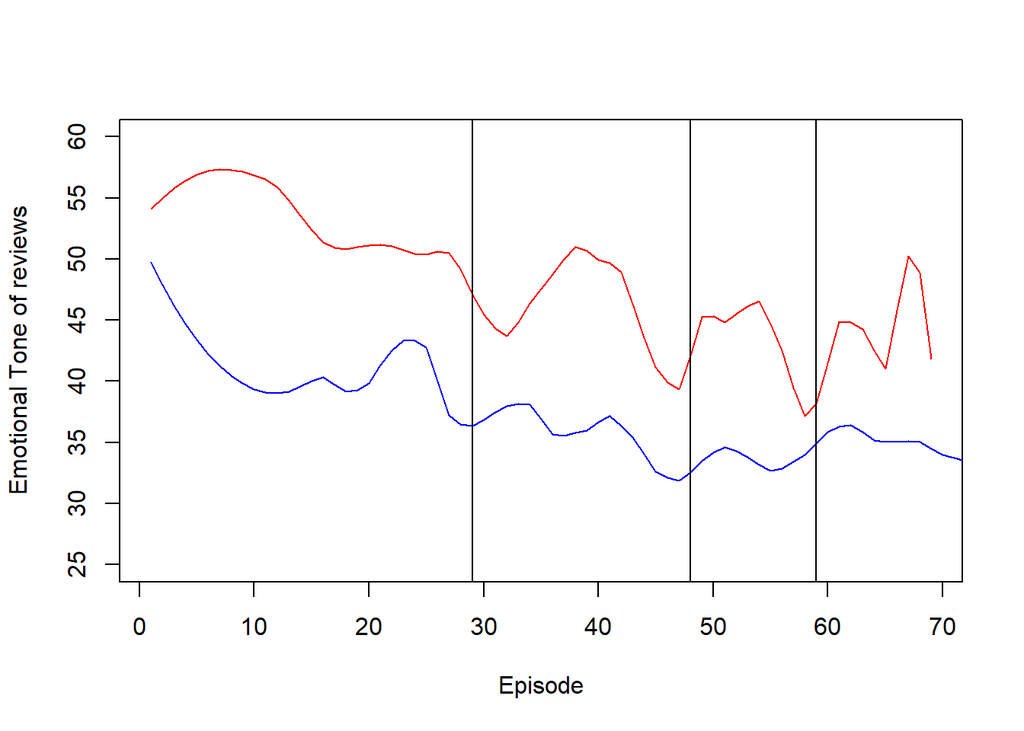

```r
#cleaning episode count missing values
dfcritics = dfcritics[dfcritics['nepisode']!='na',]
dfcritics$nepisode = as.integer(dfcritics$nepisode)
dfusers = dfusers[dfusers['n.episode']!='na',]
dfusers$n.episode = as.integer(dfusers$n.episode)
#creating a set with lenght numer of episodes
a = tapply(dfcritics$Tone, dfcritics$nepisode, mean)
b = tapply(dfusers$Tone, dfusers$n.episode, mean)

#Fit function for Critics reviews
fitToneC = loess(Tone~nepisode, data = dfcritics, span = 0.2, na.action = na.exclude)
#Get Predicted Values by episode
valsToneC = predict(fitToneC, newdata = seq(length(a)))

#Fit function for Viewers reviews
fitToneU = loess(Tone~n.episode, data = dfusers, span = 0.2, na.action = na.exclude)
#Get Predicted Values by episode
valsToneU = predict(fitToneU, newdata = seq(length(b)))

#episodes Highlits
#Pilot - 1
#Red Wedding S03E09 - 29
#The mountain and the viper S05E08 - 48
#Battle of the bastards S06E09 - 59
#Finale - 73


#Plot Critics Predicted Values
plot(y=valsToneC, x = seq(length(a)),
         type="l", xlab="Episode", ylab = "Emotional Tone of reviews", col = 'red', ylim = c(25, 60))
#Plot Viewers Predicted Values;
lines(y=valsToneU, seq(length(b)),
         type="l", xlab="Episode", ylab = "Emotional Tone of reviews", col = 'blue')

abline(v=29)
abline(v=48)
abline(v=59)
```

The Plot shows emotional tone regression models where Critics (red line) Tend to use more positive emotional tone words than viewers. And also, there is a decreasing trend of emotional Tone comparing early episodes vs last season episodes

### Comparing Emotional Tone Across Groups

to compare the emotional tone across groups we build a logistic regression model.

```r
#merging data for processing
dfcritics['group'] = 'critics'
#dfcritics['group']
dfusers['group'] = 'users'
#dfusers['group']
#data_log = as.data.frame()
merge1 = dfcritics[,c('Tone','group','Comment')]
merge2 = dfusers[,c('Tone','group','Comment')]
logistic_data = rbind(merge1,merge2)
```

```r
#building logistic regression model
model = lrm(group ~ Tone, #model formula like lm()
            data = logistic_data)

model_glm = glm(as.factor(group) ~ Tone, family = 'binomial', data = logistic_data)

model
```

```
## Logistic Regression Model
##
## lrm(formula = group ~ Tone, data = logistic_data)
##
##                        Model Likelihood       Discrimination    Rank Discrim.
##                              Ratio Test              Indexes          Indexes
## Obs         20526    LR chi2     171.41       R2       0.014    C       0.550
##  critics     3475    d.f.             1     R2(1,20526)0.008    Dxy     0.101
##  users      17051    Pr(> chi2) <0.0001    R2(1,8660.1)0.019    gamma   0.127
## max |deriv| 2e-08                             Brier    0.139    tau-a   0.028
##
##           Coef    S.E.   Wald Z Pr(>|Z|)
## Intercept  1.8556 0.0284  65.25 <0.0001
## Tone      -0.0065 0.0005 -13.24 <0.0001
```

```r
model_glm
```

```
##
## Call:  glm(formula = as.factor(group) ~ Tone, family = "binomial", data = logistic_data)
##
## Coefficients:
## (Intercept)         Tone
##    1.855609    -0.006455
##
## Degrees of Freedom: 20525 Total (i.e. Null);  20524 Residual
## Null Deviance:       18670
## Residual Deviance: 18500     AIC: 18500
```

the model is statisticaly significant, discrimination indexes indicates that the variance represented by the model is 1.4% and concordance index is 0.55, meaning that the model is not discriminating the outcomes.

### Analyzing Topics

First we create a LDA model to analyze the set of words for each topic. After Trying with several types of LDA techniques and number of topics. we set the number of topics to 5 with a gibbs LDA.

```r
#CORPUS
import_corpus = Corpus(VectorSource(logistic_data$Comment))
#doc matrix
import_mat =  DocumentTermMatrix(import_corpus,
           control = list(stemming = FALSE, #create root words
                          stopwords = TRUE, #remove stop words
                          minWordLength = 3, #cut out small words
                          removeNumbers = TRUE, #take out the numbers
                          removePunctuation = TRUE)) #take out punctuation
#word outliers
import_weight = tapply(import_mat$v/row_sums(import_mat)[import_mat$i],
                       import_mat$j,
                       mean) *
  log2(nDocs(import_mat)/col_sums(import_mat > 0))

#ignore very frequent and 0 terms
import_mat = import_mat[ , import_weight <= 0.95]
import_mat = import_mat[ row_sums(import_mat) > 0, ]

#create LDA model

k = 5 #number of topics
SEED = 777

LDA_gibbs = LDA(import_mat, k = k, method = "Gibbs",
                control = list(seed = SEED, burnin = 1000, thin = 100, iter = 1000))

#alpha smaller alpha - high percentage of documents are clasify into a single topic
LDA_gibbs@alpha
```

```
## [1] 10
```

```r
#entropy (lower value = almost everything is the same, higher value = topics are evenly spread)
sapply(list(LDA_gibbs), function (x) mean(apply(posterior(x)$topics, 1, function(z) - sum(z * log(z)))))
```

```
## [1] 1.598593
```

After creating a LDA model we can plot each word to analyze and then interpret each topic.

```r
#topis (matrix - document by Topics)
topics(LDA_gibbs, k)[1:5,1:20]
```

```
##      1 2 3 4 5 6 7 8 9 10 11 12 13 14 15 16 17 18 19 20
## [1,] 3 1 1 1 1 1 1 1 1  1  5  5  1  2  2  3  1  3  1  4
## [2,] 4 2 3 5 5 4 2 5 3  3  1  1  5  1  1  5  4  4  3  1
## [3,] 2 5 4 4 2 5 3 2 4  4  2  2  4  4  3  1  2  5  5  5
## [4,] 1 3 5 2 3 2 5 3 5  5  3  3  2  5  4  4  3  2  2  3
## [5,] 5 4 2 3 4 3 4 4 2  2  4  4  3  3  5  2  5  1  4  2
```

```r
terms(LDA_gibbs,20)
```

```
##       Topic 1      Topic 2   Topic 3    Topic 4  Topic 5
##  [1,] "episode"    "fuck"    "jon"      "like"   "show"
##  [2,] "season"     "fucking" "sansa"    "just"   "scene"
##  [3,] "one"        "now"     "will"     "arya"   "really"
##  [4,] "game"       "got"     "dany"     "see"    "well"
##  [5,] "thrones"    "going"   "back"     "can"    "books"
##  [6,] "last"       "shit"    "king"     "dont"   "still"
##  [7,] "best"       "love"    "cersei"   "know"   "book"
##  [8,] "great"      "cant"    "snow"     "get"    "also"
##  [9,] "characters" "man"     "stark"    "bran"   "much"
## [10,] "end"        "right"   "dead"     "little" "character"
## [11,] "next"       "jaime"   "daenerys" "time"   "think"
## [12,] "series"     "edit"    "come"     "way"    "made"
## [13,] "two"        "brienne" "dragons"  "anyone" "one"
## [14,] "week"       "god"     "take"     "people" "first"
## [15,] "episodes"   "die"     "westeros" "else"   "pretty"
## [16,] "many"       "tyrion"  "killed"   "didnt"  "actually"
## [17,] "battle"     "thought" "jorah"    "make"   "tyrion"
## [18,] "every"      "stannis" "night"    "want"   "better"
## [19,] "far"        "hound"   "north"    "say"    "lot"
## [20,] "ever"       "damn"    "white"    "kill"   "doesnt"
```

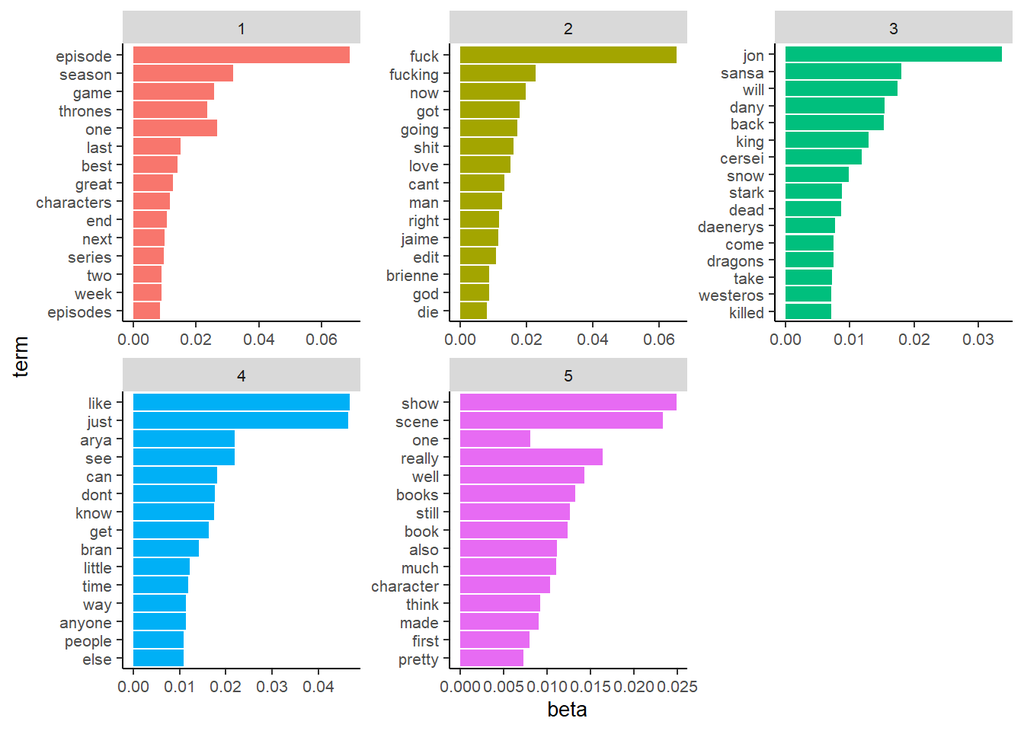

```r
LDA_fit_topics = tidy(LDA_gibbs, matrix = "beta")

#create a top terms
top_terms = LDA_fit_topics %>%
   group_by(topic) %>%
   top_n(15, beta) %>%
   ungroup() %>%
   arrange(topic, -beta)

top_terms %>%
  mutate(term = reorder(term, beta)) %>%
  ggplot(aes(term, beta, fill = factor(topic))) +
  geom_bar(stat = "identity", show.legend = FALSE) +
  facet_wrap(~ topic, scales = "free") +
  cleanup +
  coord_flip()
```

In this case each topic could be described as:

- Topic 1 - “Hype”: This topic contains a set of words mainly positive
- Topic 2 - “jaime-Briene”: This topic contains a set of words which can describe tales related to characters Jaime and Briene
- Topic 3 - “Westeros”: This topic contains a set of words related to westeros and scenes related to Jon, Sansa, Cersei and Daenerys
- Topic 4 - “arya-bran”: This topic contains a set of words related to Arya and Bran Stark
- Topic 5 - “books”: This topic contains a set of words that makes references to the books

```r
##r chunk
LDA_gamma5 = as.data.frame(tidy(LDA_gibbs, matrix = "gamma"))
LDA_gamma5 = reshape(LDA_gamma5, idvar = 'document', timevar = 'topic', direction = 'wide')

#head(LDA_gamma5)
library(dplyr)
logistic_data$document = row.names(logistic_data)
LDA_topics = merge(logistic_data, LDA_gamma5, by = 'document')

#cor.test(LDA_topics$gamma.1, LDA_topics$sentiment, method = 'spearman')
wilcox.test(LDA_topics$gamma.1~LDA_topics$group)
```

```
##
##  Wilcoxon rank sum test with continuity correction
##
## data:  LDA_topics$gamma.1 by LDA_topics$group
## W = 36227567, p-value < 2.2e-16
## alternative hypothesis: true location shift is not equal to 0
```

```r
wilcox.test(LDA_topics$gamma.2~LDA_topics$group)
```

```
##
##  Wilcoxon rank sum test with continuity correction
##
## data:  LDA_topics$gamma.2 by LDA_topics$group
## W = 11243140, p-value < 2.2e-16
## alternative hypothesis: true location shift is not equal to 0
```

```r
wilcox.test(LDA_topics$gamma.3~LDA_topics$group)
```

```
##
##  Wilcoxon rank sum test with continuity correction
##
## data:  LDA_topics$gamma.3 by LDA_topics$group
## W = 16449976, p-value < 2.2e-16
## alternative hypothesis: true location shift is not equal to 0
```

```r
wilcox.test(LDA_topics$gamma.4~LDA_topics$group)
```

```
##
##  Wilcoxon rank sum test with continuity correction
##
## data:  LDA_topics$gamma.4 by LDA_topics$group
## W = 16379366, p-value < 2.2e-16
## alternative hypothesis: true location shift is not equal to 0
```

```r
wilcox.test(LDA_topics$gamma.5~LDA_topics$group)
```

```
##
##  Wilcoxon rank sum test with continuity correction
##
## data:  LDA_topics$gamma.5 by LDA_topics$group
## W = 21535893, p-value = 0.0022
## alternative hypothesis: true location shift is not equal to 0
```

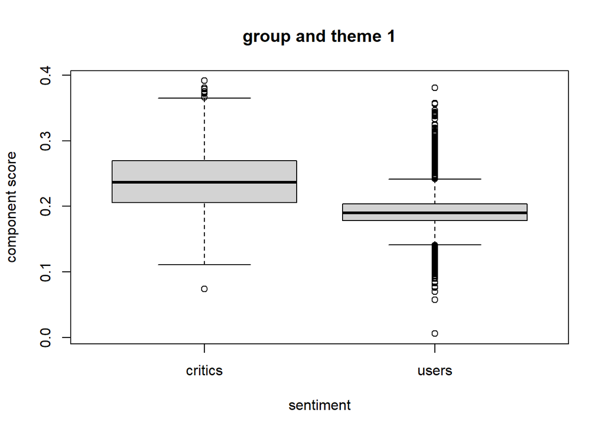

```r
#all p value less than 0.05
boxplot(gamma.1~group,data=LDA_topics, main="group and theme 1",
   xlab="sentiment", ylab="component score")
```

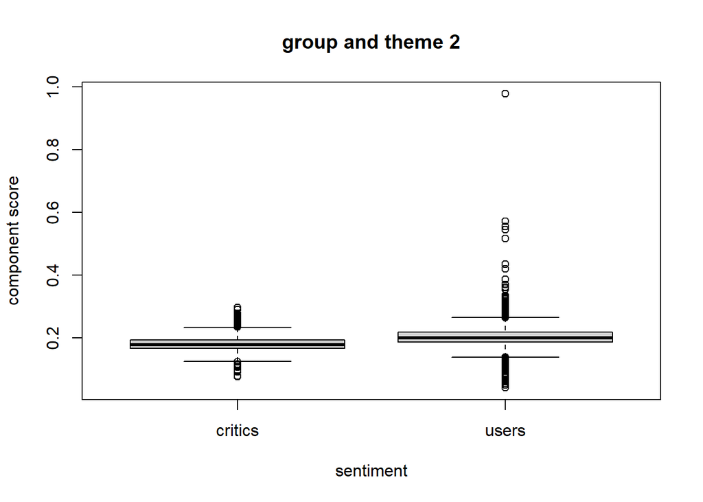

```r
boxplot(gamma.2~group,data=LDA_topics, main="group and theme 2",
   xlab="sentiment", ylab="component score")
```

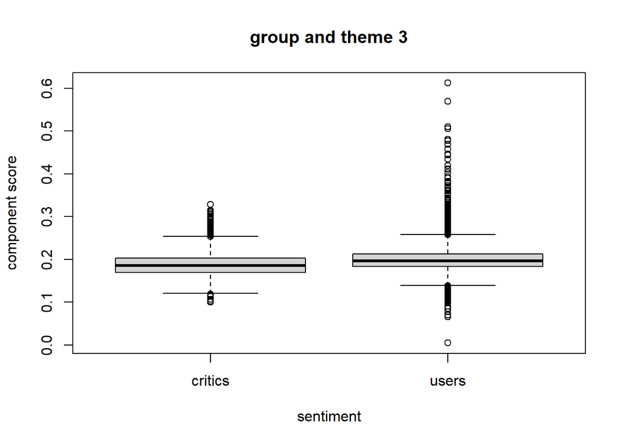

```r
boxplot(gamma.3~group,data=LDA_topics, main="group and theme 3",
   xlab="sentiment", ylab="component score")
```

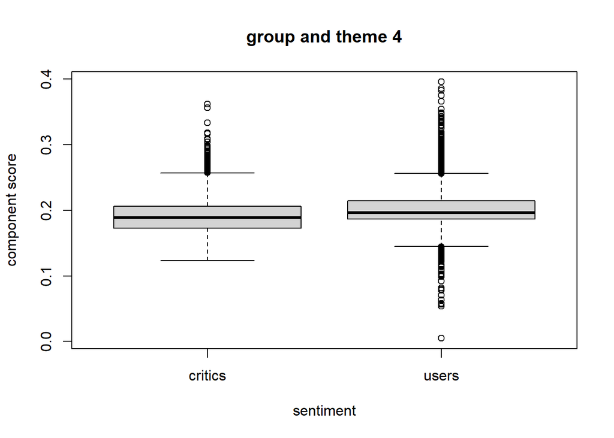

```r
boxplot(gamma.4~group,data=LDA_topics, main="group and theme 4",
   xlab="sentiment", ylab="component score")
```

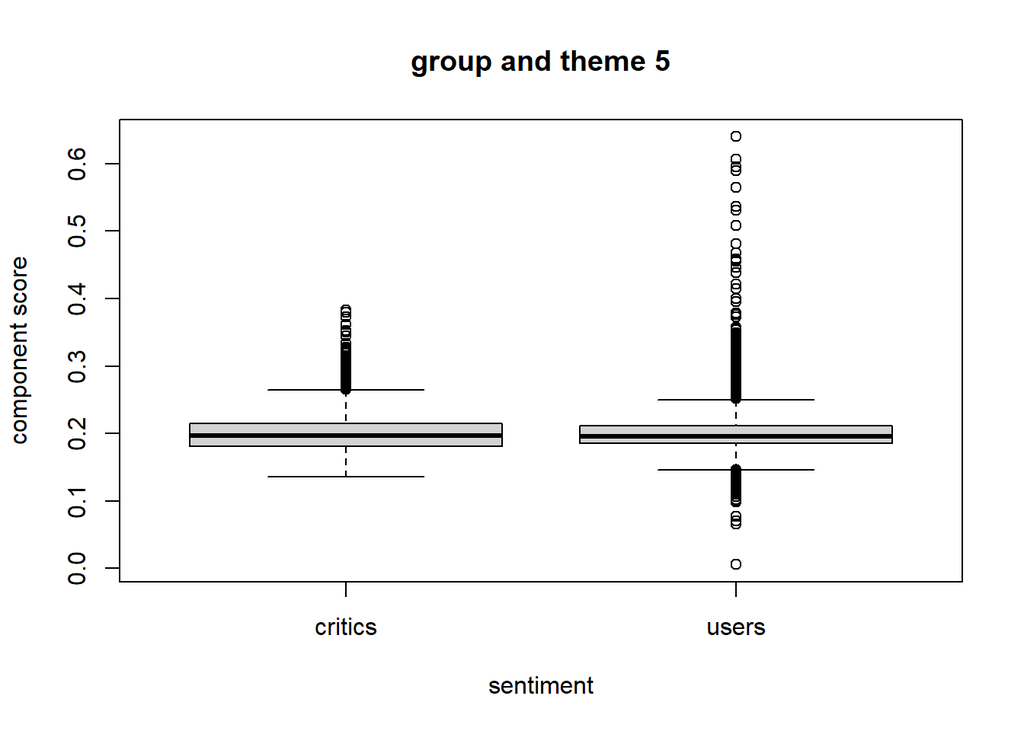

```r
boxplot(gamma.5~group,data=LDA_topics, main="group and theme 5",
   xlab="sentiment", ylab="component score")
```

## Discussion

We can see that overall the Tone trend is similar for both groups. the difference is that critics tend to use higher “emotional tone” words in their reviews. another interesting observed behavior is that top rated episodes are not placed on peak Tone values from the regression line.

Also in terms of user vs critics emotional tone in their reviews, there is no significant effect size between the two groups. we can interpret this as the Tone is not a good predictor to determine if the review was wrote by a critic or a user.

Finally, after analyzing the reviews with a topic model critics tend to write more Hyped reviews than viewers, behavior that we also see with the non parametric regression.